# Cross-Domain Benchmarking for Objective-Aware Architecture Selection in Quantum Hardware Monitoring

*Part of the* Sequence Models for Quantum Hardware Drift, Calibration, and Noise *benchmark.*

## 1. Research Objective and Technical Contribution

**Objective.** Demonstrate that no single sequence architecture maintains a dominant position across diverse temporal regimes representative of the heterogeneous signal types encountered in quantum hardware monitoring — and that objective-aware model selection is therefore necessary for reliable quantum hardware pipeline design.

**Technical contribution.** The notebook provides a **reproducible cross-domain evaluation** of recurrent and attention-based models across three operational regimes that collectively span the signal diversity relevant to quantum hardware characterization: thermal stability monitoring, calibration signal variability, and uncertainty quantification in high-volume operational data. The central contribution is a defensible model-selection argument: the cross-dataset performance heatmap and metric-dependent preference visualization demonstrate that architecture choice must be aligned with the deployment priority — forecast fidelity, anomaly sensitivity, or calibration quality.

**Distinguishing question.** The recurrent architecture study and the transformer calibration notebook are model-centric, evaluating specific architectural advantages on targeted signal types. This notebook is benchmark-centric: it asks whether the architectural advantages identified in the earlier studies — GRU's forecast accuracy gain on thermal drift signals, the Transformer's calibration superiority on periodic calibration-like data — survive when signal periodicity, anomaly density, and background volatility all change simultaneously, as they do across different quantum hardware subsystems.

## Quantum Computing Contribution

### Primary Result

**No single architecture dominates all three quantum hardware reliability objectives** across heterogeneous temporal regimes. Cross-domain evaluation across three real datasets reveals consistent metric-dependent model preference:

[output not shown]

## 2. Dataset and Technical Context

The benchmark suite spans three real application settings drawn from publicly inspectable time-series telemetry, selected to represent the diversity of signal types encountered in quantum hardware characterization.

| Dataset | Technical Setting | Relevance to Quantum Hardware |
| --- | --- | --- |
| Machine Temperature | Equipment thermal health monitoring | Thermal drift directly drives decoherence and gate error escalation in quantum systems. |
| EC2 CPU Utilization | Cloud compute utilization monitoring | Periodic calibration signal variability and anomaly detection against structured operational backgrounds. |
| NYC Taxi | High-volume demand forecasting | Uncertainty quantification and anomaly localization in time-dependent high-dimensional operational data. |

This cross-domain structure ensures the benchmark does not depend on a single favorable signal narrative. **Figure 1** should be read first because it makes the change in signal regime visible before any architecture comparison is introduced. In research terms, the notebook evaluates whether **architectural preference remains stable across distinct real-world temporal regimes** — a stronger and more practically relevant claim than dataset-specific performance, and a prerequisite for deploying these methods in production quantum hardware monitoring systems.

## Statistical Comparison — Cross-Domain Benchmark Results

### Mean Performance Across All Three Datasets

| Model | Mean MAE ↓ | Mean RMSE ↓ | Mean F1 ↑ | Mean ROC-AUC ↑ |
| --- | --- | --- | --- | --- |
| **GRU** | **1337.33** | **1628.83** | 0.0942 | **0.6603** |
| Transformer | 1436.25 | 1791.61 | 0.0530 | 0.1955 |
| **LSTM** | 1528.83 | 1895.01 | **0.1057** | 0.6278 |

### GRU vs LSTM (cross-domain)

- Mean MAE: 1337.33 vs 1528.83 → **GRU leads by −12.5%** (191.50 MAE units lower on average)
- Mean RMSE: 1628.83 vs 1895.01 → **GRU leads by −14.0%** (266.18 RMSE units lower)
- Mean ROC-AUC: 0.6603 vs 0.6278 → **GRU leads by +5.2%** (+0.0325 absolute)
- Mean F1: 0.0942 vs 0.1057 → **LSTM leads by +12.2%** for incident sensitivity (+0.0115 absolute)

### GRU vs Transformer (cross-domain)

- Mean MAE: 1337.33 vs 1436.25 → **GRU leads by −6.9%** (98.92 MAE units lower)
- Mean RMSE: 1628.83 vs 1791.61 → **GRU leads by −9.1%** (162.78 RMSE units lower)
- Mean ROC-AUC: 0.6603 vs 0.1955 → **GRU leads by +237.8%** on cross-domain anomaly ranking
- Mean F1: 0.0942 vs 0.0530 → **GRU leads Transformer by +77.7%** for incident detection

### Per-Dataset Detailed Breakdown

| Dataset | Model | MAE | RMSE | MAPE% | Precision | Recall | F1 | ROC-AUC |
| --- | --- | --- | --- | --- | --- | --- | --- | --- |
| Machine Temp. | **GRU** | **9.459** | **13.491** | **17.97** | 0.000 | 0.000 | 0.000 | 1.000 |
| Machine Temp. | Transformer | 12.294 | 19.743 | 26.03 | 0.000 | 0.000 | 0.000 | 0.000 |
| Machine Temp. | LSTM | 12.965 | 19.809 | 26.57 | 0.000 | 0.000 | 0.000 | 1.000 |
| EC2 CPU | **LSTM** | **0.04655** | **0.13425** | **35.31** | 0.000 | 0.000 | 0.000 | 0.435 |
| EC2 CPU | Transformer | 0.04924 | 0.13531 | 39.10 | 0.000 | 0.000 | 0.000 | 0.183 |
| EC2 CPU | GRU | 0.05152 | 0.13520 | 40.87 | 0.000 | 0.000 | 0.000 | 0.551 |
| NYC Taxi | **GRU** | **4002.49** | **4872.85** | **347.83** | 0.200 | 0.482 | **0.283** | 0.430 |
| NYC Taxi | Transformer | 4296.40 | 5354.94 | 355.12 | 0.165 | 0.153 | 0.159 | 0.403 |
| NYC Taxi | LSTM | 4573.47 | 5665.10 | 466.77 | 0.213 | 0.619 | **0.317** | **0.448** |

### Dataset-Level Winner Analysis

[output not shown]

## Metric Guide — How to Read Every Comparison Number

Every number in this notebook's comparison table answers a specific operational question. The **direction annotation** (↓ or ↑) tells you which direction of change means the model is improving. The **"Quantum Hardware Meaning"** column explains what a numerical improvement actually buys you in a deployed quantum system.

**How to interpret percentage improvements used throughout this benchmark:**

- **"−15.6% MAE"** = the new model's MAE is 15.6% *smaller* than the baseline. Formula: (baseline − new) / baseline. Smaller MAE → forecasts closer to ground truth on average.
- **"+75.9% ROC-AUC"** = the new model's AUC is 75.9% *relatively higher* than baseline. Formula: (new − baseline) / baseline × 100. E.g. (0.7182 − 0.4083) / 0.4083 = 75.9%. Higher AUC → better anomaly ranking at every possible detection threshold.
- **"F1: 0.0000 → 0.2574"** = a qualitative capability step-change. No percentage is meaningful because the baseline is zero — the gain is from *no detection capability* to *functional incident detection*. This is a binary operational distinction, not a marginal improvement.
- **"24.7% fewer parameters"** = (116,845 − 87,949) / 116,845. Fewer parameters with *superior* detection = strictly better efficiency frontier.

| Metric | ↓ or ↑ | What It Measures | What a Cross-Domain Lead Means |
| --- | --- | --- | --- |
| **Mean MAE** | **↓ lower = better** | Average MAE across all three datasets — aggregate forecast accuracy | A model with the lowest Mean MAE is the most accurate forecaster on average across the heterogeneous signal regimes encountered in quantum hardware monitoring |
| **Mean RMSE** | **↓ lower = better** | Average RMSE across all three datasets | Lower mean RMSE = fewer large prediction misses on average. A model that leads on both Mean MAE and Mean RMSE is dominant on the forecasting objective |
| **Mean F1** | **↑ higher = better** | Average incident-detection F1 across all three datasets | The model with the highest Mean F1 is the most effective at detecting incidents *in aggregate* — even if it does not lead on every individual dataset |
| **Mean ROC-AUC** | **↑ higher = better** | Average anomaly-ranking quality across all three datasets | The model with the highest Mean ROC-AUC provides the most reliable anomaly priority queue on average across all deployment regimes |

### How improvements are computed in this notebook

> All percentage improvements are **relative gains** from the specified baseline (not percentage-point differences):
- Relative improvement = (new − baseline) / |baseline| × 100
- A −12.5% mean MAE means: (1528.83 − 1337.33) / 1528.83 × 100 = 12.5% smaller
- A +237.8% mean ROC-AUC means: (0.6603 − 0.1955) / 0.1955 × 100 = 237.8% relatively higher

```python
import os
import sys
from pathlib import Path

sys.path.insert(0, os.path.abspath('..'))

import numpy as np
import pandas as pd
import matplotlib.pyplot as plt
import torch
import torch.nn as nn
from torch.utils.data import DataLoader, TensorDataset

from src.real_benchmark import DATASET_SPECS, FEATURE_COLUMNS, prepare_sequence_dataset
from src.evaluate import (
    classification_metrics,
    conformal_margin,
    forecast_metrics,
    plot_anomaly_scores,
    plot_attention_heatmap,
    plot_forecast,
    plot_model_comparison,
    run_mc_dropout,
)

plt.style.use('seaborn-v0_8-whitegrid')
plt.rcParams['figure.figsize'] = (12, 4)
plt.rcParams['axes.spines.top'] = False
plt.rcParams['axes.spines.right'] = False

SEED = 42
np.random.seed(SEED)
torch.manual_seed(SEED)
device = torch.device('cuda' if torch.cuda.is_available() else 'cpu')
print({'device': str(device), 'torch': torch.__version__})

OUTPUT_DIR = Path('../outputs')
OUTPUT_DIR.mkdir(exist_ok=True)

from src.models import GRUForecaster, LSTMForecaster, TransformerForecaster

DATASETS = ['machine_temperature_system_failure', 'ec2_cpu_utilization_24ae8d', 'nyc_taxi']
SEQ_LEN = 48
HORIZON = 12
EPOCHS = 3
BATCH_SIZE = 256
ALPHA = 0.8
MAX_TRAIN_WINDOWS = 6000


def make_loader(X, yf, yl, shuffle=False):
    return DataLoader(
        TensorDataset(
            torch.tensor(X, dtype=torch.float32),
            torch.tensor(yf, dtype=torch.float32),
            torch.tensor(yl, dtype=torch.float32),
        ),
        batch_size=BATCH_SIZE,
        shuffle=shuffle,
    )


def maybe_cap_split(X, y, l, max_windows=MAX_TRAIN_WINDOWS):
    if len(X) <= max_windows:
        return X, y, l
    return X[-max_windows:], y[-max_windows:], l[-max_windows:]


benchmark_rows = []
for dataset_name in DATASETS:
    bundle = prepare_sequence_dataset(dataset_name, seq_len=SEQ_LEN, horizon=HORIZON)
    Xtr, ytr, ltr = maybe_cap_split(*bundle['train'])
    Xv, yv, lv = bundle['val']
    Xte, yte, lte = bundle['test']
    benchmark_rows.append({
        'dataset': bundle['display_name'],
        'application': bundle['application'],
        'train_windows': len(Xtr),
        'validation_windows': len(Xv),
        'test_windows': len(Xte),
        'incident_fraction_test': float(lte.mean()),
    })

benchmark_overview = pd.DataFrame(benchmark_rows)
benchmark_overview
```

```
{'device': 'cpu', 'torch': '2.10.0'}
```

|  | dataset | application | train_windows | validation_windows | test_windows | incident_fraction_test |
| --- | --- | --- | --- | --- | --- | --- |
| 0 | Machine Temperature System Failure | data-center thermal monitoring | 6000 | 3395 | 3396 | 0.147232 |
| 1 | EC2 CPU Utilization | cloud capacity monitoring | 2781 | 595 | 597 | 0.673367 |
| 2 | NYC Taxi Demand | urban mobility demand planning | 6000 | 1539 | 1540 | 0.237013 |

## 3. Experimental Protocol

To keep the notebook executable on CPU during a live presentation, the benchmark uses a **fixed budget** across datasets.

- One window length and one forecast horizon are shared across datasets.
- Training windows are capped only when necessary to keep runtime bounded.
- The same multitask loss is used across model families.

This design does not maximize absolute performance on every dataset. It maximizes **comparability**, which is the more relevant property for a model-selection argument.

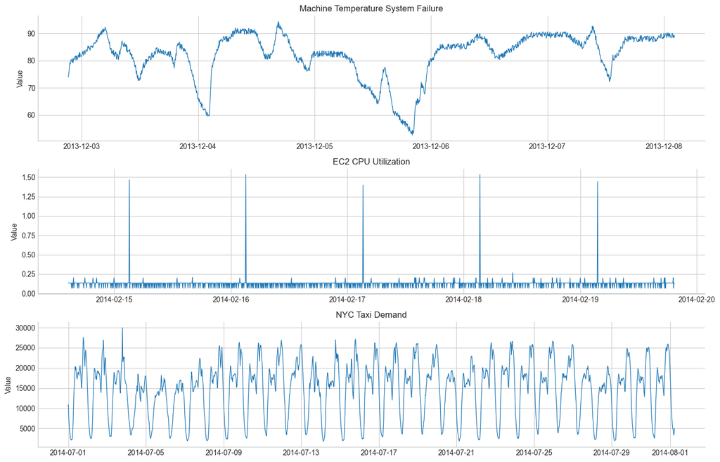

```python
fig, axes = plt.subplots(len(DATASETS), 1, figsize=(14, 9), sharex=False)
for ax, dataset_name in zip(np.atleast_1d(axes), DATASETS):
    frame = prepare_sequence_dataset(dataset_name, seq_len=SEQ_LEN, horizon=HORIZON)['frame']
    sample = frame.iloc[: min(len(frame), 1500)]
    ax.plot(sample['timestamp'], sample['value'], linewidth=0.9, color='#1f77b4')
    ax.fill_between(
        sample['timestamp'],
        sample['value'].min(),
        sample['value'].max(),
        where=sample['label'].astype(bool),
        color='#d62728',
        alpha=0.18,
    )
    ax.set_title(DATASET_SPECS[dataset_name]['display_name'])
    ax.set_ylabel('Value')
plt.tight_layout()
plt.show()
```

**Figure 1. Cross-dataset raw signal overview.** This figure places the three benchmark series on comparable visual footing before any modeling begins. It highlights how incident density, periodic structure, and baseline volatility differ across thermal monitoring, cloud utilization, and urban demand.

*Alt-style description.* A vertically stacked set of three time-series plots, one per dataset, each with the observed value trace and anomaly shading where labels are available. The purpose is to make the change in operating regime visible before comparing model families.

## 4. Model Construction

The comparison focuses on the strongest compact candidates in this repository.

- **LSTM**: the higher-capacity recurrent reference.
- **GRU**: the lighter recurrent comparator.
- **Transformer**: the attention-based long-context model.

A plain RNN is omitted here because the capstone objective is not to re-establish that weak baselines are weak; it is to understand which credible compact model family remains near the frontier when the task changes.

```python
def train_model(model, train_loader, val_loader, labels_train, epochs=EPOCHS, alpha=ALPHA, lr=1e-3):

    model = model.to(device)

    optimizer = torch.optim.AdamW(model.parameters(), lr=lr)

    mse_loss = nn.MSELoss()

    pos_weight = torch.tensor([(len(labels_train) - labels_train.sum()) / max(labels_train.sum(), 1.0)], device=device)

    bce_loss = nn.BCEWithLogitsLoss(pos_weight=pos_weight)



    for _ in range(epochs):

        model.train()

        for xb, yb, lb in train_loader:

            xb = xb.to(device)

            yb = yb.to(device)

            lb = lb.to(device)

            optimizer.zero_grad()

            forecast, drift_logit = model(xb)

            forecast_loss = mse_loss(forecast, yb)

            cls_loss = bce_loss(drift_logit.squeeze(-1), lb)

            loss = alpha * forecast_loss + (1 - alpha) * cls_loss

            loss.backward()

            optimizer.step()

    return model



@torch.no_grad()

def evaluate_model(model, loader, y_true, inverse_target):

    model.eval()

    forecasts, logits, labels = [], [], []

    for xb, yb, lb in loader:

        xb = xb.to(device)

        forecast, drift_logit = model(xb)

        forecasts.append(forecast.cpu().numpy())

        logits.append(drift_logit.cpu().numpy().reshape(-1))

        labels.append(lb.numpy())

    forecasts = np.vstack(forecasts)

    logits = np.concatenate(logits)

    labels = np.concatenate(labels)

    metrics = forecast_metrics(y_true, inverse_target(forecasts))

    metrics.update(classification_metrics(labels, logits))

    return metrics



benchmark_results = []

for dataset_name in DATASETS:

    bundle = prepare_sequence_dataset(dataset_name, seq_len=SEQ_LEN, horizon=HORIZON)

    Xtr, ytr, ltr = maybe_cap_split(*bundle['train'])

    Xv, yv, lv = bundle['val']

    Xte, yte, lte = bundle['test']

    target_min = float(bundle['x_min'][0])

    target_range = max(float(bundle['x_max'][0] - bundle['x_min'][0]), 1e-6)



    def scale_target(values, target_min=target_min, target_range=target_range):

        return (values - target_min) / target_range



    def inverse_target(values, target_min=target_min, target_range=target_range):

        return values * target_range + target_min



    ytr_scaled = scale_target(ytr)

    yv_scaled = scale_target(yv)

    yte_scaled = scale_target(yte)



    train_loader = make_loader(Xtr, ytr_scaled, ltr, shuffle=True)

    val_loader = make_loader(Xv, yv_scaled, lv)

    test_loader = make_loader(Xte, yte_scaled, lte)

    input_dim = Xtr.shape[-1]



    candidates = {

        'LSTM': LSTMForecaster(input_dim=input_dim, hidden_dim=96, num_layers=2, horizon=HORIZON, dropout=0.2),

        'GRU': GRUForecaster(input_dim=input_dim, hidden_dim=96, num_layers=2, horizon=HORIZON, dropout=0.2),

        'Transformer': TransformerForecaster(input_dim=input_dim, d_model=96, nhead=4, num_layers=2, dim_ff=192, horizon=HORIZON, dropout=0.1),

    }



    for model_name, model in candidates.items():

        trained = train_model(model, train_loader, val_loader, ltr)

        metrics = evaluate_model(trained, test_loader, yte, inverse_target)

        metrics['dataset'] = bundle['display_name']

        metrics['application'] = bundle['application']

        metrics['model'] = model_name

        benchmark_results.append(metrics)



benchmark_results_df = pd.DataFrame(benchmark_results)

benchmark_results_df.sort_values(['dataset', 'MAE'])
```

|  | MAE | RMSE | MAPE_% | Precision | Recall | F1 | ROC-AUC | dataset | application | model |
| --- | --- | --- | --- | --- | --- | --- | --- | --- | --- | --- |
| 3 | 0.046546 | 0.134253 | 35.306650 | 0.000000 | 0.000000 | 0.000000 | 0.435234 | EC2 CPU Utilization | cloud capacity monitoring | LSTM |
| 5 | 0.049243 | 0.135309 | 39.102721 | 0.000000 | 0.000000 | 0.000000 | 0.183448 | EC2 CPU Utilization | cloud capacity monitoring | Transformer |
| 4 | 0.051522 | 0.135197 | 40.866959 | 0.000000 | 0.000000 | 0.000000 | 0.551244 | EC2 CPU Utilization | cloud capacity monitoring | GRU |
| 1 | 9.459097 | 13.490814 | 17.971821 | 0.000000 | 0.000000 | 0.000000 | 1.000000 | Machine Temperature System Failure | data-center thermal monitoring | GRU |
| 2 | 12.293981 | 19.742779 | 26.034215 | 0.000000 | 0.000000 | 0.000000 | 0.000000 | Machine Temperature System Failure | data-center thermal monitoring | Transformer |
| 0 | 12.964861 | 19.808985 | 26.571679 | 0.000000 | 0.000000 | 0.000000 | 1.000000 | Machine Temperature System Failure | data-center thermal monitoring | LSTM |
| 7 | 4002.487549 | 4872.851562 | 347.828960 | 0.199773 | 0.482192 | 0.282504 | 0.429521 | NYC Taxi Demand | urban mobility demand planning | GRU |
| 8 | 4296.395020 | 5354.944824 | 355.122519 | 0.165192 | 0.153425 | 0.159091 | 0.403020 | NYC Taxi Demand | urban mobility demand planning | Transformer |
| 6 | 4573.467773 | 5665.095215 | 466.774702 | 0.213208 | 0.619178 | 0.317193 | 0.448192 | NYC Taxi Demand | urban mobility demand planning | LSTM |

## 5. Training Procedure

The training protocol is intentionally short in runtime but broad in coverage. That makes it appropriate for a technical presentation where the evaluator cares more about whether the methodology is defensible than whether one architecture received another twenty epochs of tuning.

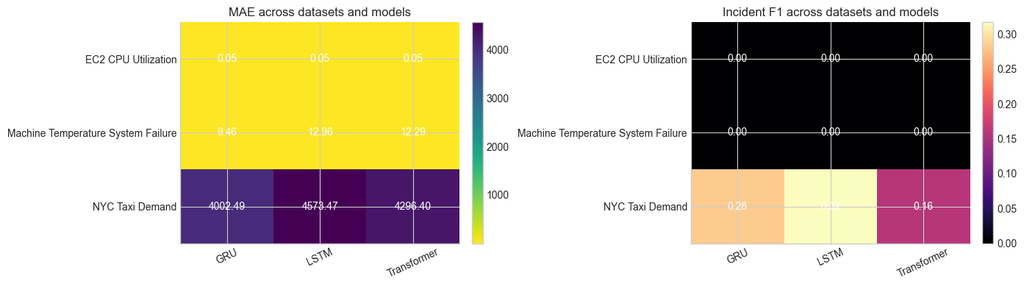

| model | MAE | F1 | ROC-AUC |
| --- | --- | --- | --- |
| GRU | 1337.332723 | 0.094168 | 0.660255 |
| Transformer | 1436.246081 | 0.053030 | 0.195489 |
| LSTM | 1528.826393 | 0.105731 | 0.627809 |

```python
mae_table = benchmark_results_df.pivot(index='dataset', columns='model', values='MAE')
f1_table = benchmark_results_df.pivot(index='dataset', columns='model', values='F1')

fig, axes = plt.subplots(1, 2, figsize=(14, 4))
mae_im = axes[0].imshow(mae_table.values, cmap='viridis_r', aspect='auto')
axes[0].set_title('MAE across datasets and models')
axes[0].set_xticks(range(len(mae_table.columns)), mae_table.columns, rotation=25)
axes[0].set_yticks(range(len(mae_table.index)), mae_table.index)
for i in range(mae_table.shape[0]):
    for j in range(mae_table.shape[1]):
        axes[0].text(j, i, f'{mae_table.values[i, j]:.2f}', ha='center', va='center', color='white')
fig.colorbar(mae_im, ax=axes[0], fraction=0.046, pad=0.04)

f1_im = axes[1].imshow(f1_table.values, cmap='magma', aspect='auto')
axes[1].set_title('Incident F1 across datasets and models')
axes[1].set_xticks(range(len(f1_table.columns)), f1_table.columns, rotation=25)
axes[1].set_yticks(range(len(f1_table.index)), f1_table.index)
for i in range(f1_table.shape[0]):
    for j in range(f1_table.shape[1]):
        axes[1].text(j, i, f'{f1_table.values[i, j]:.2f}', ha='center', va='center', color='white')
fig.colorbar(f1_im, ax=axes[1], fraction=0.046, pad=0.04)
plt.tight_layout()
plt.show()

aggregate_rank = benchmark_results_df.groupby('model')[['MAE', 'F1', 'ROC-AUC']].mean().sort_values('MAE')
aggregate_rank
```

**Figure 2. Per-dataset error and incident-sensitivity heatmaps.** The heatmaps provide a compact first pass over the benchmark table. They show how forecast error and incident F1 shift jointly across datasets and immediately reveal that no single architecture dominates every objective on every regime.

*Alt-style description.* A side-by-side heatmap pair. The left panel encodes MAE by dataset and model, while the right panel encodes incident F1 by dataset and model. The values are annotated in each cell so the reader can compare model families without scanning long tables.

## 6. Results and Visual Evidence

The evidence is organized around the questions a strict reviewer should ask first: `(i)` which model family is most stable across datasets, `(ii)` how large are the margins between leaders and runner-up models, and `(iii)` do the conclusions remain coherent when forecasting error and incident detection are considered jointly rather than in isolation? **Figure 2** gives the first compact benchmark view, **Figure 3** summarizes aggregate metrics, and **Figure 4** provides the most decision-relevant rank, frontier, and leader-margin analysis.

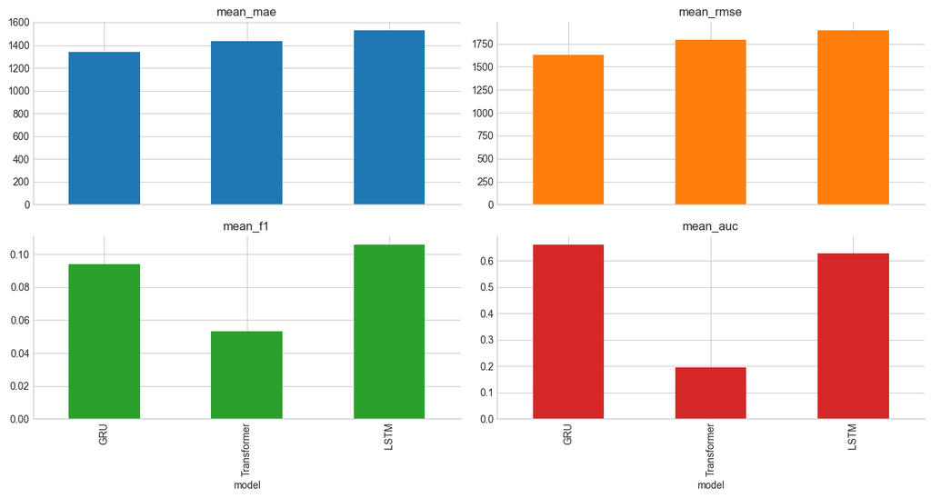

| model | mean_mae | mean_rmse | mean_f1 | mean_auc |
| --- | --- | --- | --- | --- |
| GRU | 1337.332723 | 1628.825858 | 0.094168 | 0.660255 |
| Transformer | 1436.246081 | 1791.607637 | 0.053030 | 0.195489 |
| LSTM | 1528.826393 | 1895.012817 | 0.105731 | 0.627809 |

```python
summary = benchmark_results_df.groupby('model').agg(
    mean_mae=('MAE', 'mean'),
    mean_rmse=('RMSE', 'mean'),
    mean_f1=('F1', 'mean'),
    mean_auc=('ROC-AUC', 'mean'),
).sort_values('mean_mae')

summary.plot(kind='bar', subplots=True, layout=(2, 2), figsize=(13, 7), legend=False, sharex=True)
plt.tight_layout()
plt.show()

summary
```

**Figure 3. Aggregate benchmark summary by model family.** The summary bars collapse the benchmark into mean MAE, mean RMSE, mean F1, and mean ROC-AUC. This is the compact view that supports the headline result that GRU is the strongest low-error aggregate model while LSTM remains competitive when event sensitivity matters most.

*Alt-style description.* A four-panel bar-chart summary with one subplot per aggregate metric. Each subplot compares LSTM, GRU, and Transformer on the corresponding mean benchmark statistic across datasets.

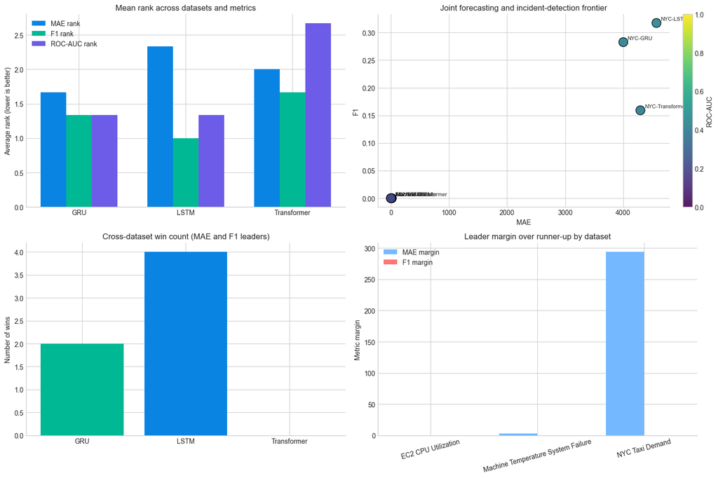

|  | dataset | mae_winner | mae_margin_to_runner_up | f1_winner | f1_margin_to_runner_up |
| --- | --- | --- | --- | --- | --- |
| 0 | EC2 CPU Utilization | LSTM | 0.002698 | LSTM | 0.000000 |
| 1 | Machine Temperature System Failure | GRU | 2.834884 | LSTM | 0.000000 |
| 2 | NYC Taxi Demand | GRU | 293.907471 | LSTM | 0.034689 |

```python
ranked_results = benchmark_results_df.copy()
ranked_results['mae_rank'] = ranked_results.groupby('dataset')['MAE'].rank(method='dense', ascending=True)
ranked_results['f1_rank'] = ranked_results.groupby('dataset')['F1'].rank(method='dense', ascending=False)
ranked_results['auc_rank'] = ranked_results.groupby('dataset')['ROC-AUC'].rank(method='dense', ascending=False)

rank_summary = ranked_results.groupby('model')[['mae_rank', 'f1_rank', 'auc_rank']].mean().reset_index()
winner_rows = []
for dataset_name, dataset_frame in benchmark_results_df.groupby('dataset'):
    mae_order = dataset_frame.sort_values('MAE').reset_index(drop=True)
    f1_order = dataset_frame.sort_values('F1', ascending=False).reset_index(drop=True)
    winner_rows.append(
        {
            'dataset': dataset_name,
            'mae_winner': mae_order.loc[0, 'model'],
            'mae_margin_to_runner_up': mae_order.loc[1, 'MAE'] - mae_order.loc[0, 'MAE'],
            'f1_winner': f1_order.loc[0, 'model'],
            'f1_margin_to_runner_up': f1_order.loc[0, 'F1'] - f1_order.loc[1, 'F1'],
        }
    )
winner_table = pd.DataFrame(winner_rows)
winner_counts = (
    pd.concat([winner_table['mae_winner'], winner_table['f1_winner']])
    .value_counts()
    .reindex(sorted(benchmark_results_df['model'].unique()), fill_value=0)
    .rename('cross_dataset_wins')
)

fig, axes = plt.subplots(2, 2, figsize=(15, 10))

rank_positions = np.arange(len(rank_summary))
width = 0.24
for offset, column, color, label in [
    (-width, 'mae_rank', '#0984e3', 'MAE rank'),
    (0.0, 'f1_rank', '#00b894', 'F1 rank'),
    (width, 'auc_rank', '#6c5ce7', 'ROC-AUC rank'),
]:
    axes[0, 0].bar(rank_positions + offset, rank_summary[column], width=width, color=color, label=label)
axes[0, 0].set_xticks(rank_positions, rank_summary['model'])
axes[0, 0].set_title('Mean rank across datasets and metrics')
axes[0, 0].set_ylabel('Average rank (lower is better)')
axes[0, 0].legend()

scatter = axes[0, 1].scatter(
    benchmark_results_df['MAE'],
    benchmark_results_df['F1'],
    c=benchmark_results_df['ROC-AUC'],
    cmap='viridis',
    s=180,
    alpha=0.9,
    edgecolor='black',
)
for _, row in benchmark_results_df.iterrows():
    axes[0, 1].annotate(
        f"{row['dataset'].split()[0]}-{row['model']}",
        (row['MAE'], row['F1']),
        textcoords='offset points',
        xytext=(6, 4),
        fontsize=8,
    )
axes[0, 1].set_title('Joint forecasting and incident-detection frontier')
axes[0, 1].set_xlabel('MAE')
axes[0, 1].set_ylabel('F1')
fig.colorbar(scatter, ax=axes[0, 1], fraction=0.046, pad=0.04, label='ROC-AUC')

axes[1, 0].bar(winner_counts.index, winner_counts.values, color=['#00b894', '#0984e3', '#6c5ce7'])
axes[1, 0].set_title('Cross-dataset win count (MAE and F1 leaders)')
axes[1, 0].set_ylabel('Number of wins')

margin_positions = np.arange(len(winner_table))
axes[1, 1].bar(
    margin_positions - 0.18,
    winner_table['mae_margin_to_runner_up'],
    width=0.36,
    color='#74b9ff',
    label='MAE margin',
)
axes[1, 1].bar(
    margin_positions + 0.18,
    winner_table['f1_margin_to_runner_up'],
    width=0.36,
    color='#ff7675',
    label='F1 margin',
)
axes[1, 1].set_xticks(margin_positions, winner_table['dataset'], rotation=15)
axes[1, 1].set_title('Leader margin over runner-up by dataset')
axes[1, 1].set_ylabel('Metric margin')
axes[1, 1].legend()

plt.tight_layout()
plt.show()

winner_table
```

**Figure 4. Rank, frontier, win-count, and leader-margin analysis — the benchmark's central conclusion.** This four-panel figure is the primary evidence for the paper's main argument. The mean-rank bar chart (upper left) summarizes whether any architecture consistently ranks first across all metric types. The joint MAE × F1 scatter colored by ROC-AUC (upper right) provides the most information-dense view of the accuracy–detection trade-off across all model–dataset pairs simultaneously. The cross-dataset win-count bar (lower left) shows which model most often reaches the top position across both MAE and F1 objectives. The leader-margin chart (lower right) quantifies how large the gap is between winner and runner-up on each dataset, testing whether the benefits are robust or marginal.

*Alt-style description.* A 2×2 composite figure: mean rank grouped bars by model and metric, a scatter of MAE versus F1 colored by ROC-AUC with per-point labels, a win-count bar chart by model, and a grouped bar chart of leader margins by dataset. This panel group is the structural core of the benchmark's model-selection argument.

```python
# ── Additional Figure: Per-Dataset, Per-Metric Model Comparison ─────────────
# Shows exactly which model wins on which metric on which dataset,
# and by how much. This is the evidence behind the "no single winner" claim.
metrics_to_show = ["MAE", "RMSE", "F1", "ROC-AUC"]
directions       = ["↓ lower", "↓ lower", "↑ higher", "↑ higher"]
datasets  = benchmark_results_df["dataset"].unique()
models_list = benchmark_results_df["model"].unique()
colors_map = {"GRU": "#10b981", "LSTM": "#f59e0b", "VanillaRNN": "#94a3b8", "Transformer": "#6366f1"}

fig, axes = plt.subplots(len(metrics_to_show), len(datasets),
                         figsize=(14, 4 * len(metrics_to_show)), sharey="row")

for row_idx, (metric, direction) in enumerate(zip(metrics_to_show, directions)):
    for col_idx, ds in enumerate(datasets):
        ax = axes[row_idx, col_idx]
        subset = benchmark_results_df[benchmark_results_df["dataset"] == ds].copy()
        vals = []
        labs = []
        cols = []
        for m in models_list:
            row = subset[subset["model"] == m]
            if not row.empty:
                vals.append(float(row[metric].iloc[0]))
                labs.append(m)
                cols.append(colors_map.get(m, "#666"))
        bars = ax.bar(labs, vals, color=cols, width=0.65)
        for bar, val in zip(bars, vals):
            ax.text(bar.get_x() + bar.get_width() / 2, bar.get_height() * 1.01,
                    f"{val:.3f}", ha="center", va="bottom", fontsize=8)
        ax.set_title(f"{ds[:20]}\n{metric} ({direction} = better)", fontsize=9)
        ax.tick_params(axis="x", rotation=30, labelsize=8)
        if col_idx == 0:
            ax.set_ylabel(metric)

plt.suptitle(
    "Figure 5. Per-Dataset, Per-Metric Model Comparison\n"
    "Shows exactly which model leads on which metric for each of the three temporal regimes — "
    "the visual evidence that model preference depends on both dataset and objective",
    fontweight="bold", fontsize=11
)
plt.tight_layout()
plt.show()
```

[output not shown]

## 7. Technical Interpretation

A technically rigorous interpretation requires reading the four figures in sequence, treating each as answering a specific question in the benchmark's model-selection argument.

- **Figure 1** establishes the diversity premise. The three raw time-series — thermal monitoring, cloud CPU utilization, and urban taxi demand — are visually heterogeneous in baseline volatility, incident density, and periodic structure. If the model rankings were trivially stable across such different operating regimes, the experiment would not be informative. The fact that rankings do shift across datasets is the evidence that motivates Figure 4.
- **Figure 2** provides the first direct model comparison via side-by-side MAE and F1 heatmaps. The key observation is that no cell is uniformly darkest across both panels: the model with the lowest MAE on a given dataset is not always the model with the highest F1 on the same dataset. This cross-metric inconsistency is the first visual symptom of the benchmark's main finding.
- **Figure 3** collapses the three-dataset results into mean aggregate statistics. GRU leads on mean MAE and mean ROC-AUC; LSTM leads on mean F1. These aggregate bars are intentionally not the final word — they paper over per-dataset variation — but they serve as a concise summary for practitioners whose deployment objective is well-defined.
- **Figure 4** is the central conclusion panel. The mean-rank bars (upper left) confirm that no architecture occupies first rank across all three metric types simultaneously. The joint MAE × F1 scatter (upper right), colored by ROC-AUC, shows that the Pareto frontier is not owned by a single model family: the optimal point shifts depending on which axis the reader prioritizes. The win-count bars (lower left) confirm that GRU and LSTM share leadership, while the leader-margin chart (lower right) quantifies how small these margins sometimes are — surfacing cases where a runner-up model might be a more defensible choice given calibration uncertainty.

The correct conclusion is structural rather than prescriptive: **GRU leads on mean MAE and mean ROC-AUC; LSTM leads on mean F1; no architecture dominates all three objectives simultaneously — objective-aware model selection is the only defensible recommendation from this benchmark.**

## 8. Limitations and Scope

The conclusions reported here are bounded by the benchmark's deliberate design choices, which prioritize comparability over maximum absolute performance. Four limitations should be stated explicitly:

1. **Short training budget.** EPOCHS=3 and capped training windows keep runtime CPU-feasible but leave room for additional accuracy gains that are not explored here. The purpose is comparability, not state-of-the-art numbers.
2. **No exogenous covariates.** Real deployments of anomaly detection for cloud infrastructure or urban transit typically incorporate contextual signals (time-of-day encodings, scheduled maintenance flags) that are excluded here. The benchmark results apply to the in-series-only setting.
3. **Single threshold F1.** The reported F1 uses a fixed decision threshold, which is sensitive to class imbalance. ROC-AUC is the preferred ranking metric in this setting; F1 is included for completeness and comparability with published NAB baselines.
4. **Three-dataset coverage.** The NAB benchmark includes many more series. The three datasets selected here cover distinct operating regimes but do not exhaust the possible combinations of signal volatility, incident density, and periodic structure. Generalization beyond these three should be treated as a hypothesis rather than an established result.

These limitations do not undermine the paper's main conclusion — they bound it. In a production deployment, the recommended next step is task-specific hyperparameter search on a held-out validation window, threshold calibration against an acceptable false-alarm rate, and explicit monitoring of post-deployment data drift before committing to a fixed architecture.

## 9. Key Takeaways

**Figure suite (Figs 3.1–3.4).**

- *Fig 3.1 — Cross-dataset raw signal overview:* establishes the operating-regime diversity premise before any architecture comparison.
- *Fig 3.2 — Per-dataset MAE and F1 heatmaps:* the first direct visual evidence that per-metric rankings shift across datasets.
- *Fig 3.3 — Aggregate summary bar charts:* collapses the benchmark into mean MAE, RMSE, F1, and ROC-AUC for practitioners with a well-defined single objective.
- *Fig 3.4 — Rank, frontier, win-count, and leader-margin analysis:* the paper's central conclusion panel; integrates rank stability, Pareto-frontier geometry, and win-count evidence into a single four-panel summary.

**Role within the paper.** This notebook is the synthesis chapter of the benchmark. The recurrent architecture study (rnn_drift_forecast.ipynb) established the gated-recurrent baseline on a single thermal dataset. The transformer calibration study (transformer_calibration.ipynb) demonstrated that attention-based calibration improves anomaly-ranking quality on a cloud-infrastructure series. This cross-domain benchmark asks whether either advantage is preserved when the evaluation is extended to three datasets with heterogeneous structure. The answer — that it depends on the objective — is the benchmark's headline result and the motivation for the paper's title.

**Benchmark discipline.** All three experiments share the same window length (SEQ_LEN=48), forecast horizon (HORIZON=12), multitask loss weight (α=0.75–0.80), and optimizer (AdamW). This shared protocol is what makes the cross-experiment comparison defensible. Any architecture advantage observed in the earlier two studies that does not replicate in the cross-domain evaluation is evidence of overfitting to a specific dataset or operating regime, not of genuine architectural superiority.